# Walkthrough - Mixture models and multidimensional scaling

Jeff

Feb 25, 2026

## Mixture Models

Keeping in mind that mixture model families can often take some time to fit, we will restrict the number of models considered during many of the model fits for brevity of the lab. I certainly encourage you to explore the softwares in more depth.

First, let’s run the popular `mclust` package on the faithful data set

```r
#install.packages("mclust")
#install.packages("teigen")
library(mclust)
mfaith <- Mclust(faithful, G=1:5)
```

Rather than scrolling a large table of values, you can view a plot of the BIC values. The X-axis is the number of groups for the clustering solution (called components of the mixture model), and the Y-axis is the BIC (model fitting measure). Each of the covariance structures we discussed in class has a different line on the plot.

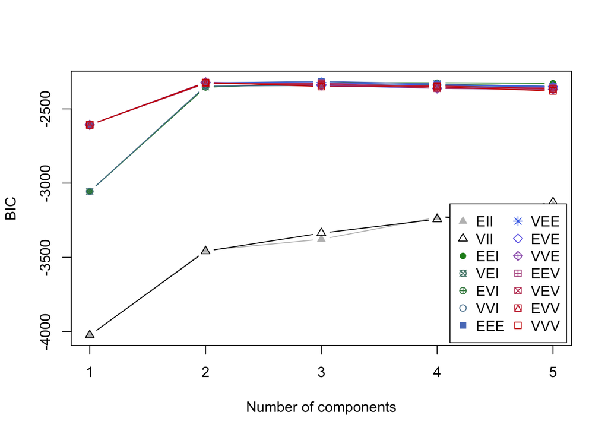

```r
plot(mfaith, what="BIC")
```

The classification plot will provide a visual of each mixture component overlaid on top of the fitted groups.

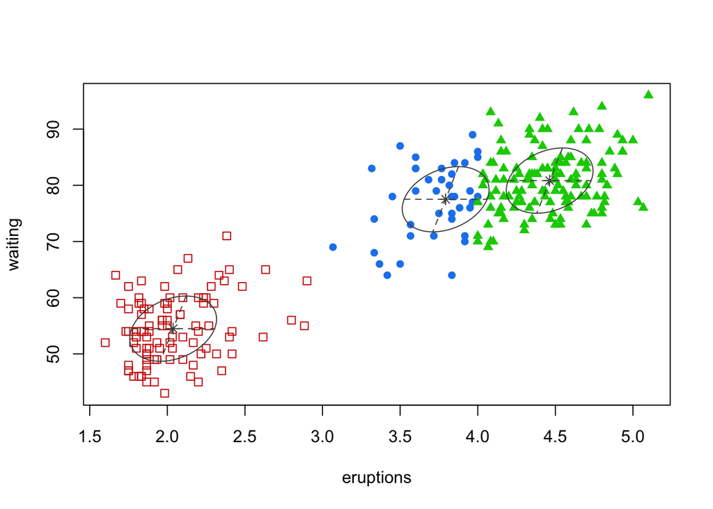

```r
plot(mfaith, what="classification")
```

The uncertainty plot gives you a visual of which observations have relatively unclear classification. The larger the point appears, the more uncertain in the classification we are.

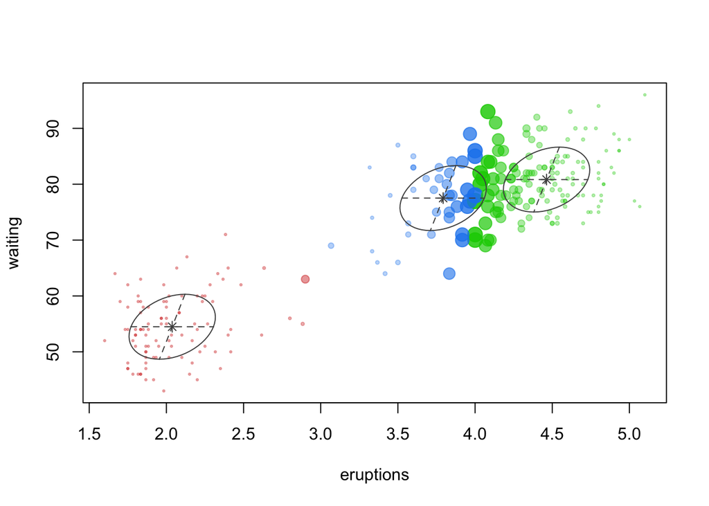

```r
plot(mfaith, what="uncertainty")
```

Finally, the density plot will provide the contours of the actual fitted mixture model.

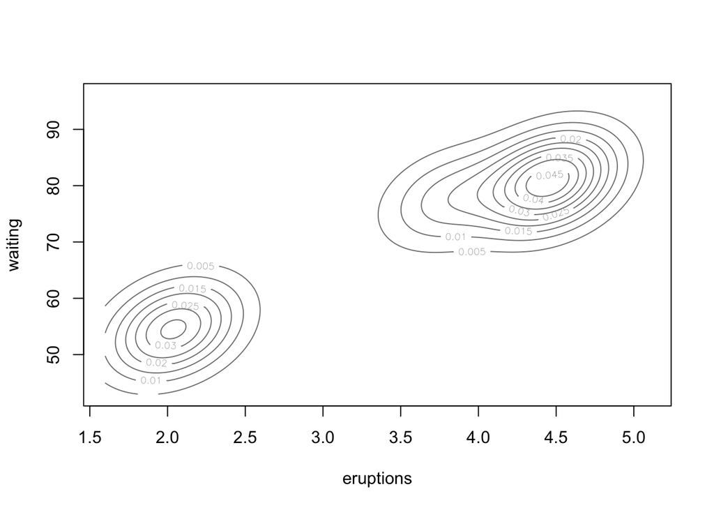

```r
plot(mfaith, what="density")
```

Other software is available for similar models under different distributional assumptions. Here’s an example on some of Jeff’s software, which uses the multivariate t distribution and eigendecomposition constraints on the covariance matrix.

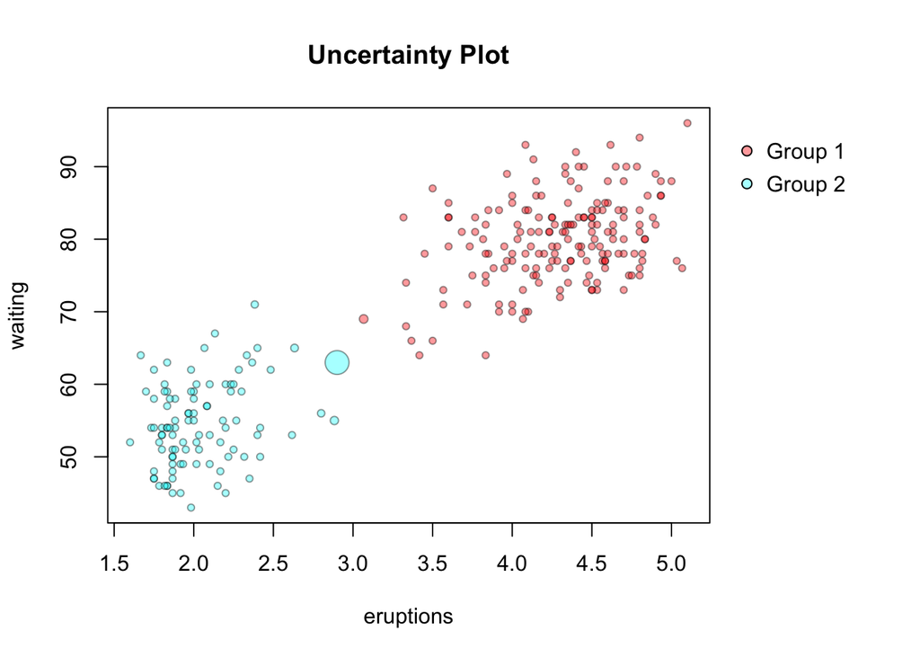

```r
library(teigen)
tfaith <- teigen(faithful, Gs=1:5, model="UUUU", scale=FALSE, verbose = FALSE)
plot(tfaith, what="uncertainty")
```

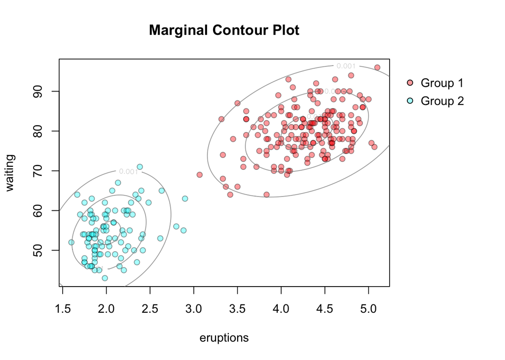

```r
plot(tfaith, what="contour")
```

The faithful data set is a true unsupervised problem as we don’t have known labels. But we can take a look at some of our supervised data sets to investigate how these clustering methods perform with respect to known groups…

```r
library(gclus)
```

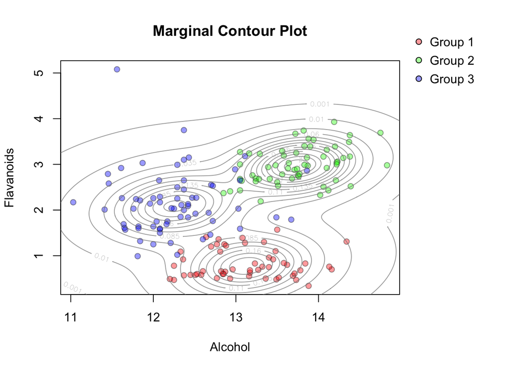

```r
data(wine)
twine <- teigen(wine[,-1], Gs=1:5, model="UCCU", scale=FALSE, verbose=FALSE)
plot(twine, xmarg=1, ymarg=7, what="contour")
```

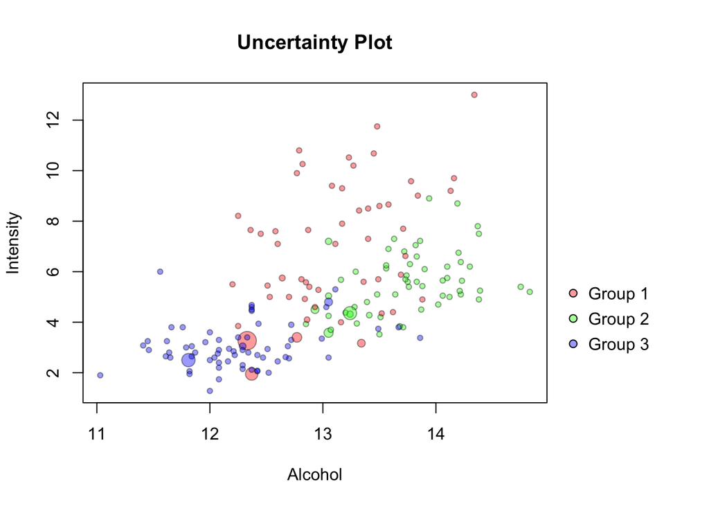

```r
plot(twine, xmarg=1, ymarg=10, what="uncertainty")
```

```r
table(wine[,1], twine$classification)
```

```
##
##      1  2  3
##   1  0 59  0
##   2  5  0 66
##   3 48  0  0
```

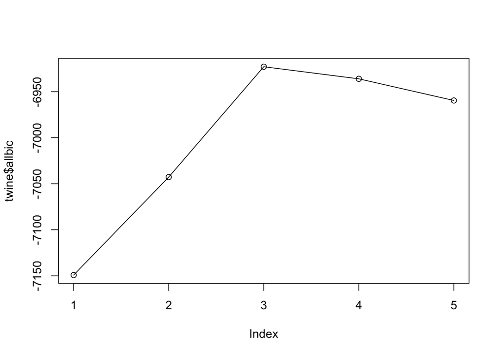

```r
plot(twine$allbic, type="l")
points(twine$allbic)
```

And so we can see (for at least one covariance structure from tEIGEN), that the G=3 group model is chosen on the wine data via the BIC, and the resulting clusters match quite closely to the known group varietals in the data (5 misclassifications).

We can check the ARI using the function from mclust…

```r
adjustedRandIndex(wine[,1], twine$classification)
```

```
## [1] 0.9188052
```

## Multidimensional Scaling

“As of mid-2018, the Google Maps Platform requires a registered API key”, so the gmaps example shown on lecture slides is no longer as simple to go through.

How do we do on a similar, non-local map? In R, there is a distance matrix for a bunch of European cities:

```r
labels(eurodist)
```

```
##  [1] "Athens"          "Barcelona"       "Brussels"        "Calais"
##  [5] "Cherbourg"       "Cologne"         "Copenhagen"      "Geneva"
##  [9] "Gibraltar"       "Hamburg"         "Hook of Holland" "Lisbon"
## [13] "Lyons"           "Madrid"          "Marseilles"      "Milan"
## [17] "Munich"          "Paris"           "Rome"            "Stockholm"
## [21] "Vienna"
```

If we run MDS on this distance matrix, we get the following results:

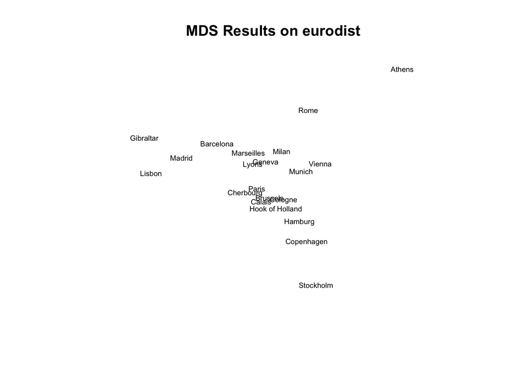

```r
plot(cmdscale(eurodist)[,1], cmdscale(eurodist)[,2], type = "n", xlab = "", ylab = "", asp = 1, axes = FALSE, main = "MDS Results on eurodist")
text(cmdscale(eurodist)[,1], cmdscale(eurodist)[,2], rownames(cmdscale(eurodist)), cex = 0.6)
```

Again, something’s not right. Specifically, we would expect Stockholm to be the most northern city of the bunch and Athens to be the most southern. Let’s simply multiply the second column by -1.

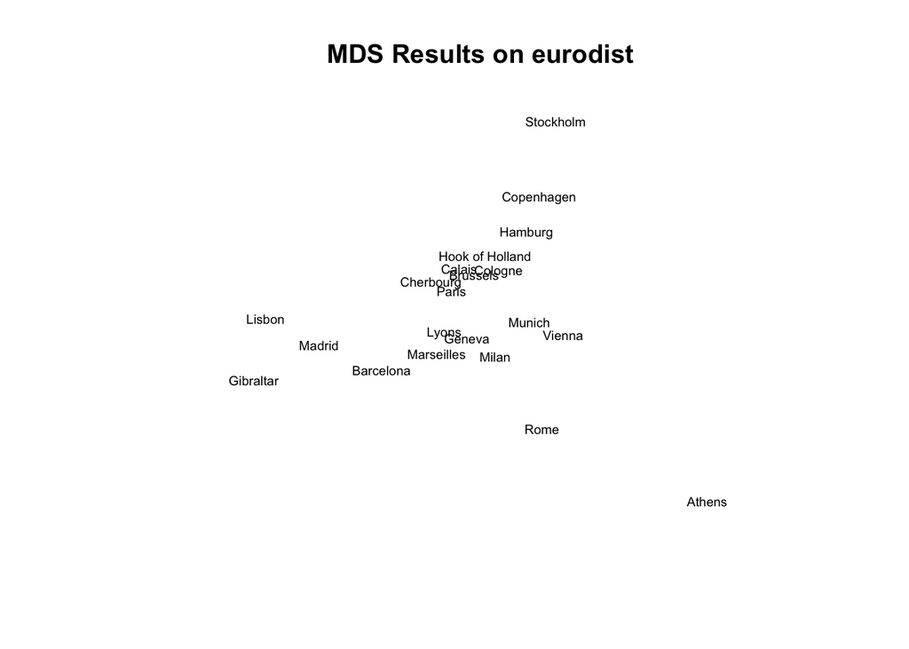

```r
plot(cmdscale(eurodist)[,1], -cmdscale(eurodist)[,2], type = "n", xlab = "", ylab = "", asp = 1, axes = FALSE, main = "MDS Results on eurodist")
text(cmdscale(eurodist)[,1], -cmdscale(eurodist)[,2], rownames(cmdscale(eurodist)), cex = 0.6)
```

This is more promising, you can compare to the europecircled.png file on Github to see how well MDS has done.